# 👩‍🔬 Simulation-Based Methods versus Theory-Based Methods

What did we just do?

We carried out a hypothesis test!

$$H_0: \beta_1 = 0$$

$$H_A: \beta_1 \neq 0$$

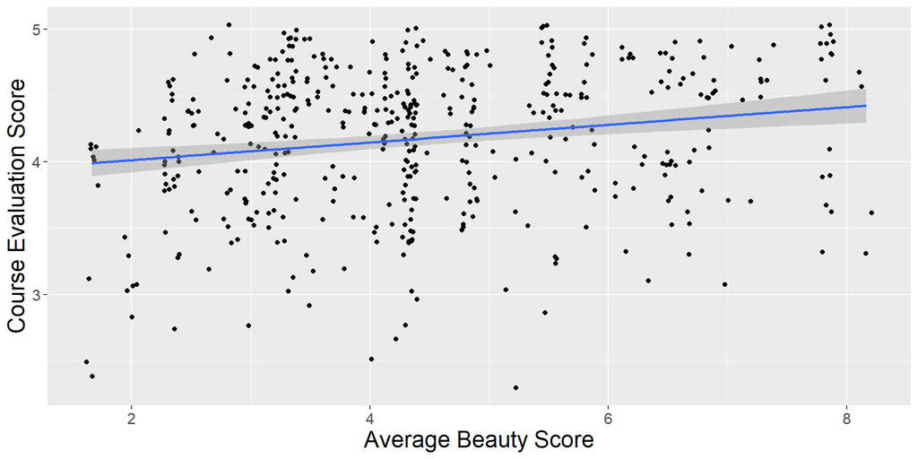

What do these hypotheses mean *in words*?

By creating a permutation distribution!

```r
null_dist <- evals %>%
  specify(response = score,
          explanatory = bty_avg) %>%
  hypothesise(null = "independence") %>%
  generate(reps = 1000, type = "permute") %>%
  calculate(stat = "slope")
```

What is happening in the `generate()` step?

And visualizing where our observed statistic fell on the distribution

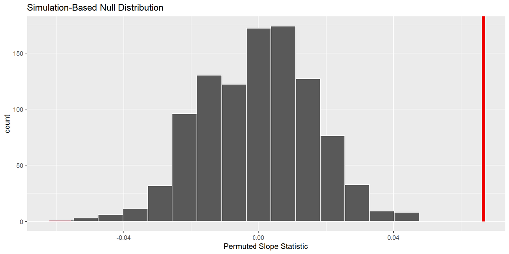

What would you estimate the p-value to be?

And calculated the p-value

```r
get_p_value(null_dist,
            obs_stat = obs_slope,
            direction = "two-sided")
```

```
# A tibble: 1 × 1
  p_value
    <dbl>
1       0
```

What would you decide for your hypothesis test?

How would this process have changed if we used theory-based methods instead?

Approximating the permutation distribution

A $t$-distribution can be a reasonable approximation for the permutation distribution if certain conditions are not violated.

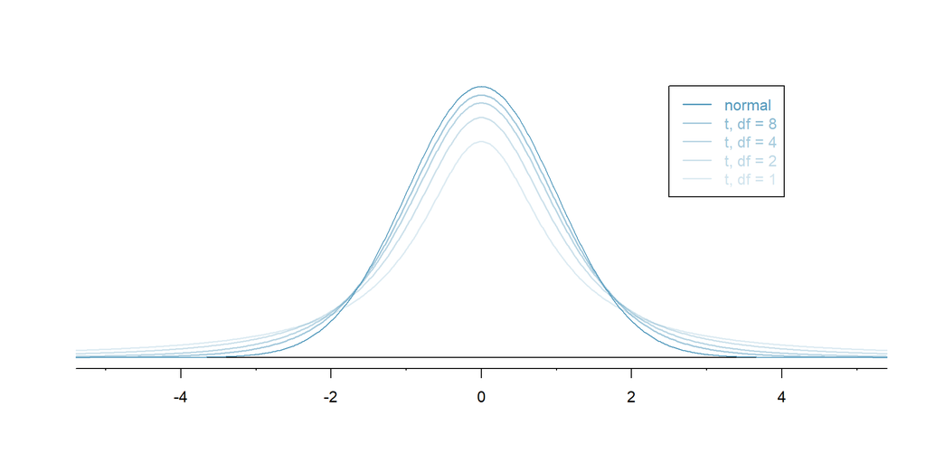

What about the observed statistic?

- Before
- Now

```r
obs_slope <- evals %>%
  specify(response = score,
          explanatory = bty_avg) %>%
  calculate(stat = "slope")
```

```
Response: score (numeric)
Explanatory: bty_avg (numeric)
# A tibble: 1 × 1
    stat
   <dbl>
1 0.0666
```

```r
evals_lm <- lm(score ~ bty_avg,
               data = evals)

get_regression_table(evals_lm)
```

```
# A tibble: 2 × 7
  term      estimate std_error statistic p_value lower_ci upper_ci
  <chr>        <dbl>     <dbl>     <dbl>   <dbl>    <dbl>    <dbl>
1 intercept    3.88      0.076     51.0        0    3.73     4.03
2 bty_avg      0.067     0.016      4.09       0    0.035    0.099
```

How did R calculate the $t$-statistic?

- Step 1: SE
- Step 2: t-statistic
- Proof!

$SE_{b_1} = \frac{\frac{s_y}{s_x} \cdot \sqrt{1 - r^2}}{\sqrt{n - 2}}$

```
[1] 0.01495204
```

$t = \frac{b_1}{SE_{b_1}}$

[output not shown]

```
# A tibble: 2 × 7
  term      estimate std_error statistic p_value lower_ci upper_ci
  <chr>        <dbl>     <dbl>     <dbl>   <dbl>    <dbl>    <dbl>
1 intercept    3.88      0.076     51.0        0    3.73     4.03
2 bty_avg      0.067     0.016      4.09       0    0.035    0.099
```

How does R calculate the p-value?

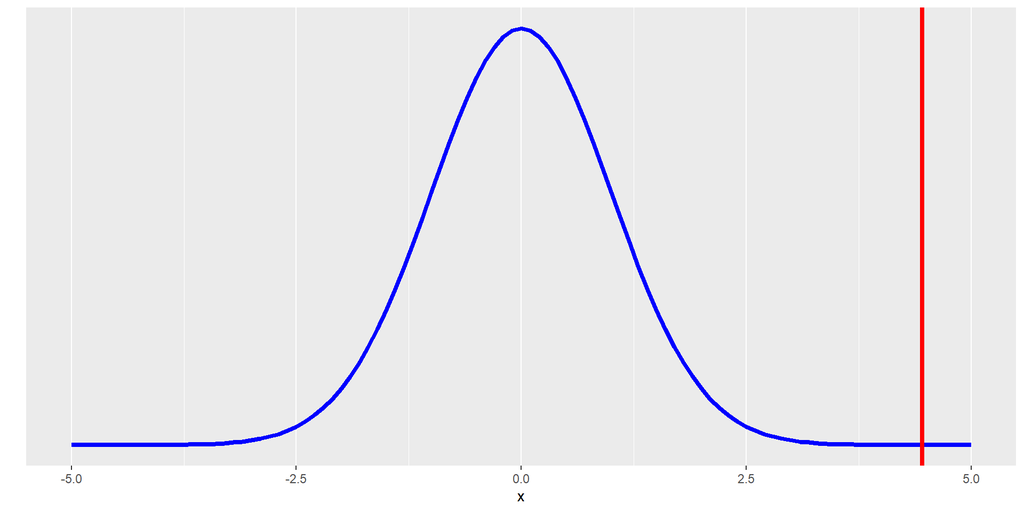

**How many degrees of freedom does this $t$-distribution have?**

Why not always use theoretical methods?

Theory-based methods only hold if the sampling distribution is normally shaped.

The normality of a sampling distribution depends **heavily** on model conditions.

What are these “conditions”?

For linear regression we are assuming…

**L**inear relationship between $x$ and $y$

**I**ndepdent observations

**N**ormality of residuals

**E**qual variance of residuals

**L**inear relationship between $x$ and $y$

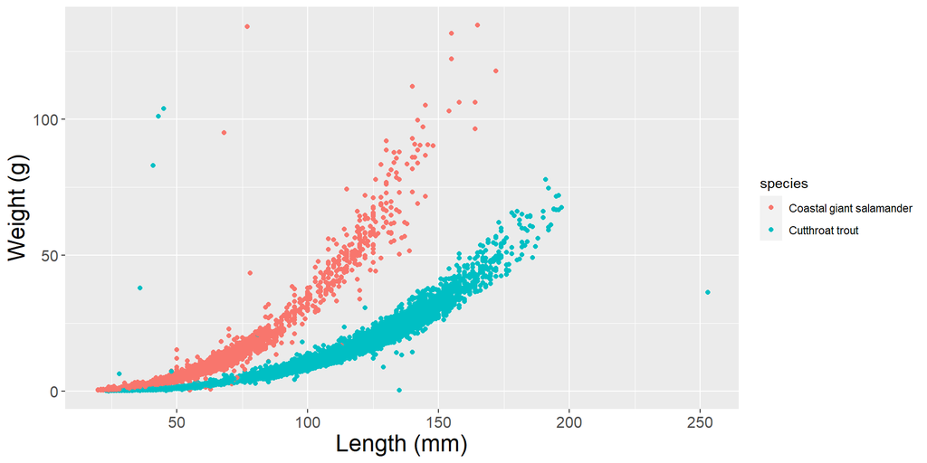

**What should we do?**

Variable transformation!

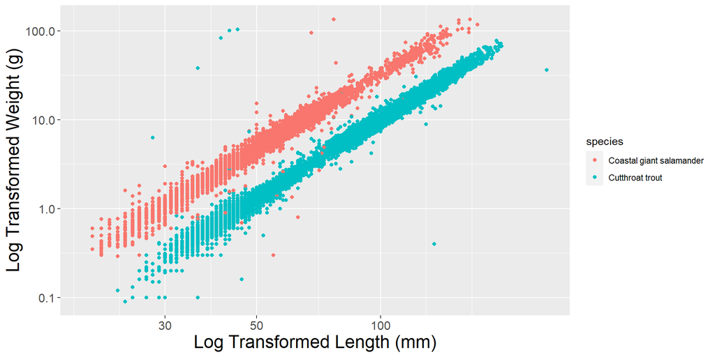

**I**ndependence of observations

The `evals` dataset contains 463 observations on 94 professors. Meaning, professors have **multiple** observations.

*What can we do?*

**Best** – use a random effects model

**Reasonable** – collapse the multiple scores into a single score

**N**ormality of residuals

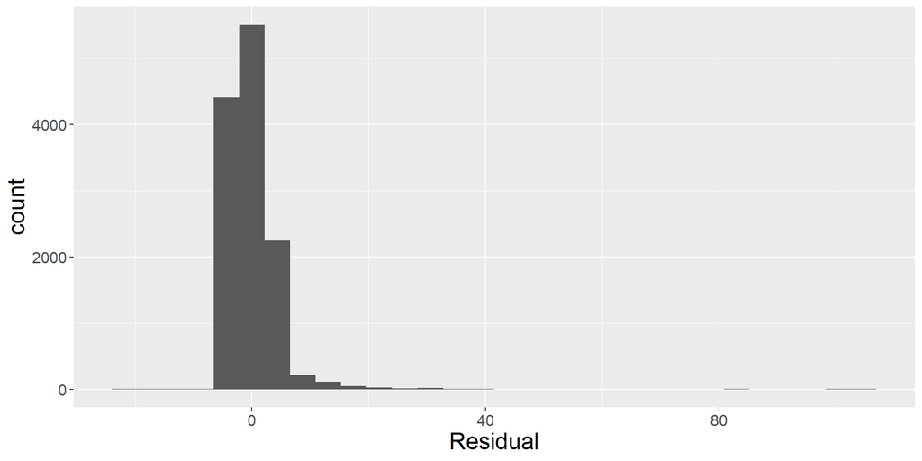

**What should we do?**

Variable transformation!

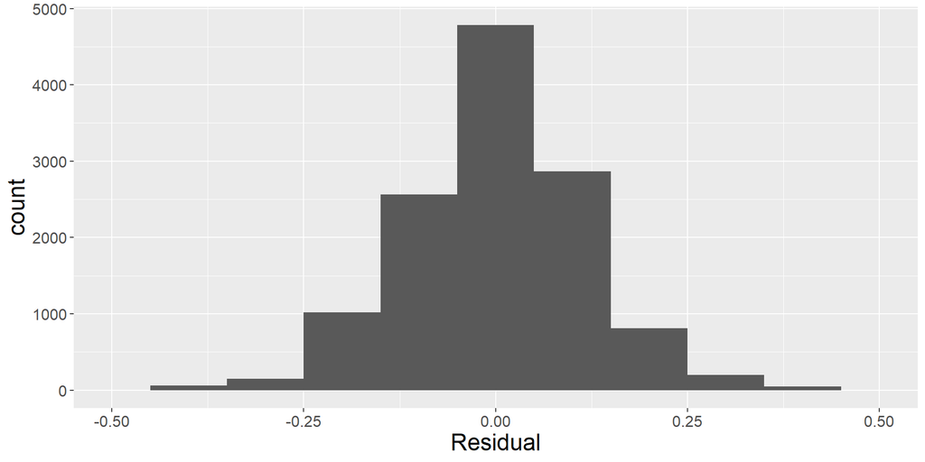

**E**qual variance of residuals

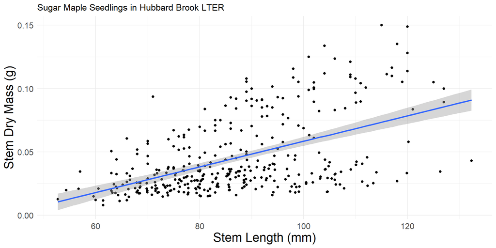

**What should we do?**

Variable transformation!

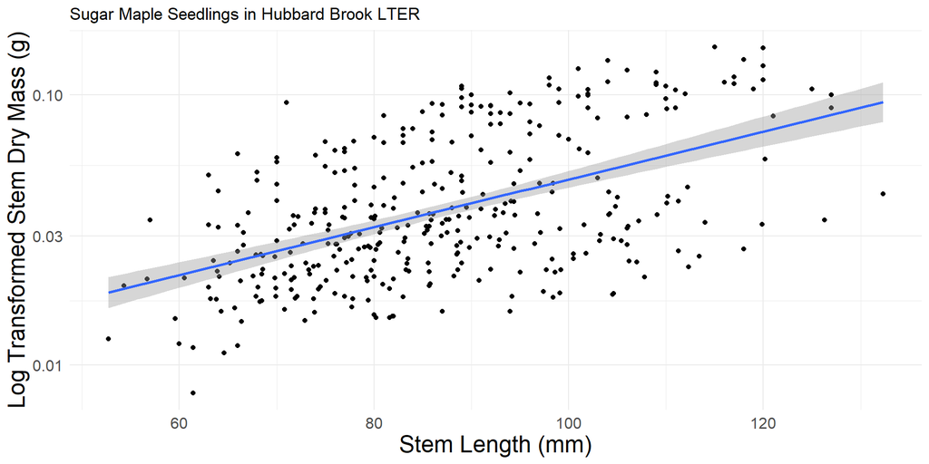

Are these conditions required for **both** methods?

Simulation-based Methods

- Linearity of Relationship
- Independence of Observations
- Equal Variance of Residuals

Theory-based Methods

- Linearity of Relationship
- Independence of Observations
- Normality of Residuals
- Equal Variance of Residuals

What happens if the conditions are violated?

In general, when the conditions associated with these methods are violated, the permutation and $t$-distributions will underestimate the true standard error of the sampling distribution.